# Exploring the BRFSS data

## Setup

### Load packages

```r
library(ggplot2)
library(dplyr)
```

### Load data

```r
load("brfss2013.RData")
```

## Part 1: Data

##About our Data Our Data is a complete survey of the health status and health issues of adult U.S. citizens which is conducted by BRFSS.The dataset “brfss2013” contains the data of *491775* randomly selected citizens and have a total of *330* variables. The data is Non - Response bias since the data only comes from people willing to answer the call and going through the long survey

##Process of Data Collection Data from 50 U.S. states, the District of Columbia, and three U.S. territories is collected and more than 400,000 adult BRFSS surveys are conducted every year. The Survey is taken using landline or celephone telephones

1. In conducting the BRFSS landline telephone survey, interviewers collect data from a randomly selected adult in a household
2. In conducting the cellular telephone version of the BRFSS questionnaire, interviewers collect data from an adult who participates by using a cellular telephone and resides in a private residence or college housing.

####Scope of inference

##Data is Generalizable Since the data is collected by sampling random adults from each household. Also none of the researchers interfered with the data hence its an observational study.The data is collected through stratified sampling and the sampling is random hence data is generalizable

##Data is Non Causal Since the participants were not randomly assigned to groups for specific tasks this cannot be identified as an experimental study and hence no causality can be inferred

## Part 2: Research questions

**Research quesion 1:** Is there any correlation between people who smoked at least 100 cigarettes and use smokeless tobacco products Every day, in having other type of cancer(not skin cancer)? Variables: smoke100,usenow3,chcocncr

Reason for the question: It is believed that people who smoke and use smokeless tobacco are prone to getting cancer, this research question is used to show the statistics in the answers of yes and no with a fair count

**Research quesion 2:** Is there a correlation between sleeptime, mental health and physical health? Variables: sleptim1,menthlth,physhlth

Reason for the question: It is believed that people who sleep very less or very much are more prone to having bad physical health and bad mental health, this research question is used to show the statistics of whether there is a correlation or not between the entities

**Research quesion 3:** Can gender(respondent’s sex) and income level be correlated with poor physical or mental health ? variables: poorhlth,income2,sex

Reason for the question: The question is to brief the possibility that different genders at different income levels experience different levels of healthiness. It is believed that more males than females experience poor health and it is also believed that higher the salary of a person the less is the chance of the person having poor health. These two things can be easily answered with a detailed plot through data analysis. * * *

## Part 3: Exploratory data analysis

**Research quesion 1:**

```r
sm_100 <- brfss2013 %>%
  filter(!is.na(smoke100),!is.na(usenow3),!is.na(chcocncr))

##summary stats
cancer100 <- sm_100 %>%
  group_by(chcocncr) %>%
  summarise(smoke_and_tob = sum(smoke100 == 'Yes',usenow3 == 'Every day'))
cancer100
```

```
## # A tibble: 2 x 2
##   chcocncr smoke_and_tob
##   <fct>            <int>
## 1 Yes              25011
## 2 No              197638
```

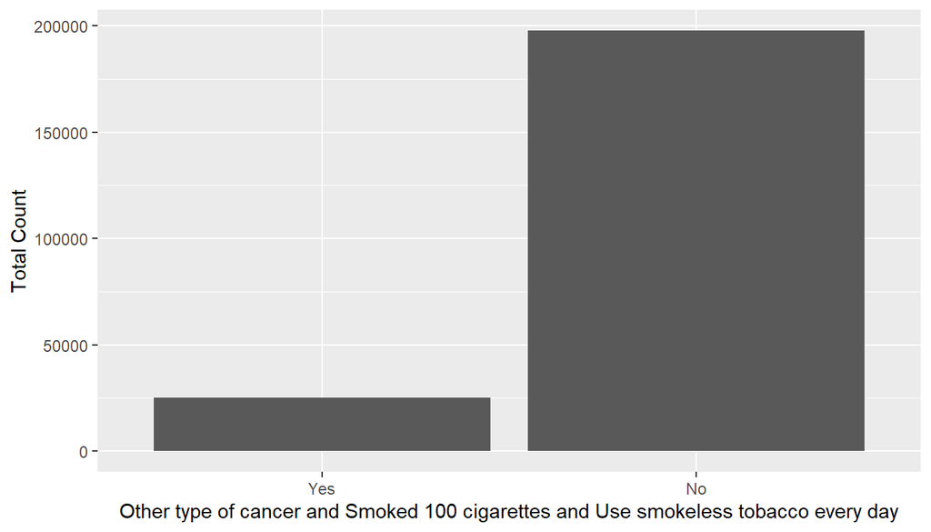

```r
##plot
ggplot(data = cancer100,aes(x = chcocncr , y = smoke_and_tob ))+geom_bar(stat = 'identity')+ylab('Total Count')+xlab('Other type of cancer and Smoked 100 cigarettes and Use smokeless tobacco every day')
```

**Research quesion 2:**

```r
##Creating a small data sample for easy calculations
sampledata = brfss2013[70000:90000,]
sampledata = tbl_df(sampledata)
##Summary Statistics
stats = summarize(sampledata, "sleptim1", mean(sleptim1, na.rm=T))
colnames(stats) = c("Variable", "mean")
physhlthmean = summarize(sampledata, "physhlth", mean(physhlth, na.rm=T))
colnames(physhlthmean) = c("Variable", "mean")
menthlthmean = summarize(sampledata, "menthlth", mean(menthlth, na.rm=T))
colnames(menthlthmean) = c("Variable", "mean")
stats = rbind(stats, physhlthmean,menthlthmean)

stats
```

```
## # A tibble: 3 x 2
##   Variable  mean
##   <chr>    <dbl>
## 1 sleptim1  7.09
## 2 physhlth  5.35
## 3 menthlth  3.72
```

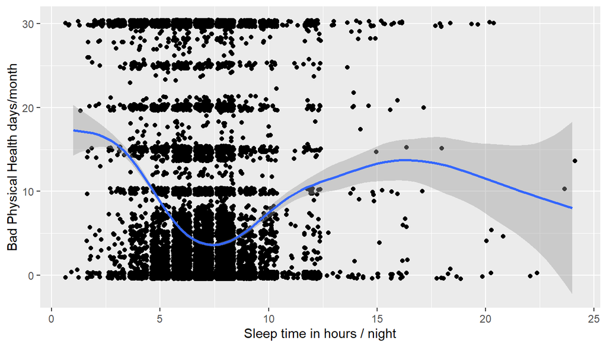

```r
##Plot for correlation between sleeptime and physical health
ggplot(sampledata, aes(y= physhlth, x = sleptim1)) + geom_jitter() +geom_smooth()+labs(x="Sleep time in hours / night", y="Bad Physical Health days/month")
```

```r
##Correlation Value for sleeptime and physical health
cor(sampledata$sleptim1,sampledata$physhlth,use ="complete.obs")
```

```
## [1] -0.09275033
```

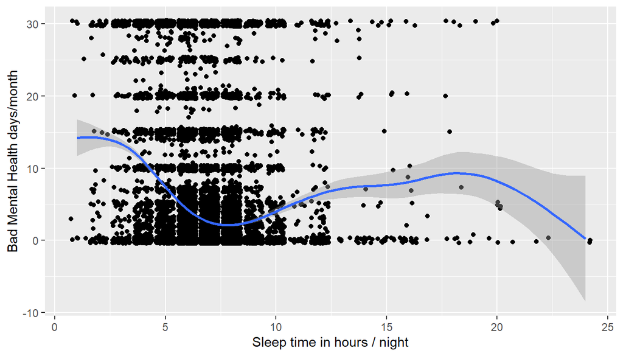

```r
##Plot for correlation between sleeptime and mental health
ggplot(sampledata, aes(y= menthlth, x = sleptim1)) + geom_jitter() +geom_smooth()+labs(x="Sleep time in hours / night", y="Bad Mental Health days/month")
```

```r
##Correlation value for sleeptime and mental health
cor(sampledata$sleptim1,sampledata$menthlth,use ="complete.obs")
```

```
## [1] -0.163537
```

##Narative  
In visual representation of physical health and sleeptime and mental health and sleeptime we find that there is no clear correlation or linear relationship and even the correlation value is negative which is not significant, But in the visual representations we can barely see some dips in plotted regression line which shows that people on both extremes can have higher chances of having bad physical or mental health days per month

**Research quesion 3:**

```r
healthtable <- brfss2013 %>% filter(!(is.na(sex)), !(is.na(poorhlth)), !(is.na(income2)))
healthtable <- healthtable %>% mutate(poorhlth = ifelse(poorhlth > 8, "9+", poorhlth))
healthtable$poorhlth <- factor(healthtable$poorhlth)

##Summary Statistics
healthtable %>% group_by(income2, sex) %>% summarize(count=n())
```

```
## # A tibble: 16 x 3
## # Groups:   income2 [8]
##    income2           sex    count
##    <fct>             <fct>  <int>
##  1 Less than $10,000 Male    5402
##  2 Less than $10,000 Female 11819
##  3 Less than $15,000 Male    5708
##  4 Less than $15,000 Female 11683
##  5 Less than $20,000 Male    7176
##  6 Less than $20,000 Female 13550
##  7 Less than $25,000 Male    8251
##  8 Less than $25,000 Female 15054
##  9 Less than $35,000 Male    9397
## 10 Less than $35,000 Female 15778
## 11 Less than $50,000 Male   11888
## 12 Less than $50,000 Female 18124
## 13 Less than $75,000 Male   12354
## 14 Less than $75,000 Female 18558
## 15 $75,000 or more   Male   21116
## 16 $75,000 or more   Female 28900
```

```r
healthtable %>% group_by(poorhlth, sex) %>% summarize(count=n())
```

```
## # A tibble: 20 x 3
## # Groups:   poorhlth [10]
##    poorhlth sex    count
##    <fct>    <fct>  <int>
##  1 0        Male   46658
##  2 0        Female 74760
##  3 1        Male    4197
##  4 1        Female  6690
##  5 2        Male    4558
##  6 2        Female  7644
##  7 3        Male    2799
##  8 3        Female  4692
##  9 4        Male    1570
## 10 4        Female  2697
## 11 5        Male    2796
## 12 5        Female  5106
## 13 6        Male     526
## 14 6        Female   828
## 15 7        Male    1421
## 16 7        Female  2752
## 17 8        Male     354
## 18 8        Female   648
## 19 9+       Male   16413
## 20 9+       Female 27649
```

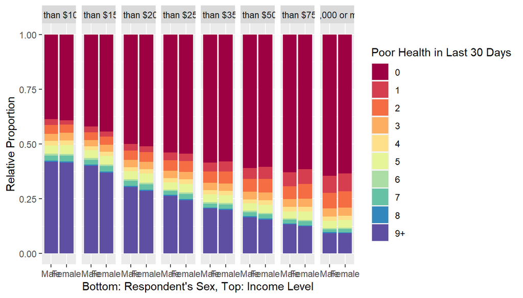

```r
##Plot
plot <- ggplot(healthtable) + aes(x = sex, fill = poorhlth) + geom_bar(position = "fill") + facet_grid(.~income2)
plot <- plot + scale_fill_brewer(name="Poor Health in Last 30 Days", palette = "Spectral") + xlab("Bottom: Respondent's Sex, Top: Income Level") + ylab("Relative Proportion")
plot
```